# Análisis Exploratorio de los Datos (AED)

El primer paso es decargar el dataset de Kaggle (https://www.kaggle.com/datasets/fedesoriano/stellar-classification-dataset-sdss17):

Después de descargar el dataset original de Kaggle, leo el dataset e imprimo 10 muestras aleatorias.

```python
import pandas as pd

df = pd.read_csv("data/star_classification.csv")
df.sample(10)
```

|  | obj_ID | alpha | delta | u | g | r | i | z | run_ID | rerun_ID | cam_col | field_ID | spec_obj_ID | class | redshift | plate | MJD | fiber_ID |
| --- | --- | --- | --- | --- | --- | --- | --- | --- | --- | --- | --- | --- | --- | --- | --- | --- | --- | --- |
| 43491 | 1.237661e+18 | 132.188844 | 55.409378 | 21.85590 | 21.76357 | 19.59877 | 18.92891 | 18.61436 | 3600 | 301 | 3 | 21 | 5.803080e+18 | GALAXY | 0.377776 | 5154 | 55864 | 698 |
| 96481 | 1.237658e+18 | 146.988513 | 47.757536 | 26.54753 | 23.05740 | 21.37866 | 20.18710 | 19.35186 | 2821 | 301 | 2 | 39 | 8.228282e+18 | GALAXY | 0.664629 | 7308 | 56709 | 747 |
| 84614 | 1.237662e+18 | 173.244301 | 41.910974 | 27.02709 | 21.22178 | 19.35458 | 18.54292 | 17.94336 | 3840 | 301 | 4 | 117 | 1.624808e+18 | GALAXY | 0.475266 | 1443 | 53055 | 489 |
| 14703 | 1.237674e+18 | 128.257932 | 20.841777 | 25.10129 | 23.01238 | 22.13021 | 21.99653 | 21.85486 | 6597 | 301 | 2 | 221 | 1.077057e+19 | GALAXY | 0.511745 | 9566 | 58083 | 772 |
| 5914 | 1.237664e+18 | 48.164606 | -1.059920 | 20.71461 | 19.48631 | 18.65866 | 18.22762 | 17.96057 | 4263 | 301 | 1 | 437 | 4.638840e+17 | GALAXY | 0.170791 | 412 | 52258 | 48 |
| 24256 | 1.237662e+18 | 229.382103 | 37.496512 | 20.47902 | 18.42705 | 17.18186 | 16.71797 | 16.34389 | 3926 | 301 | 3 | 26 | 1.576354e+18 | GALAXY | 0.186693 | 1400 | 53470 | 343 |
| 90834 | 1.237679e+18 | 350.333772 | 23.488665 | 23.43348 | 22.09431 | 22.47003 | 22.27442 | 22.61159 | 7708 | 301 | 2 | 146 | 8.634653e+18 | STAR | -0.000084 | 7669 | 57329 | 460 |
| 76058 | 1.237662e+18 | 233.631968 | 37.434300 | 23.11127 | 21.57392 | 19.73038 | 18.82032 | 18.42915 | 3958 | 301 | 2 | 30 | 5.603688e+18 | GALAXY | 0.505741 | 4977 | 56047 | 305 |
| 7220 | 1.237669e+18 | 279.617502 | 41.965520 | 19.56714 | 18.62678 | 18.27508 | 18.11507 | 18.06686 | 5416 | 301 | 5 | 130 | 3.174046e+18 | STAR | -0.000392 | 2819 | 54617 | 488 |
| 38703 | 1.237652e+18 | 219.978029 | 2.778417 | 22.99227 | 22.82827 | 20.81239 | 19.83478 | 19.34519 | 1458 | 301 | 5 | 635 | 4.527440e+18 | GALAXY | 0.525580 | 4021 | 55620 | 715 |

Como hay varias columnas del dataset que no me interesan, concretamente 4, ya que contienen información irrelevante, las elimino:

```python
# Selecciono solo las columnas de interés
columns_to_keep = ['alpha', 'delta', 'u', 'g', 'r', 'i', 'z',
                   'field_ID', 'spec_obj_ID', 'redshift', 'plate',  'MJD', 'fiber_ID', 'class']

# Creo el nuevo dataframe con las columnas que me interesan
df_star_class_clean = df[columns_to_keep]
df_star_class_clean.sample(10)
```

|  | alpha | delta | u | g | r | i | z | field_ID | spec_obj_ID | redshift | plate | MJD | fiber_ID | class |
| --- | --- | --- | --- | --- | --- | --- | --- | --- | --- | --- | --- | --- | --- | --- |
| 40650 | 147.229415 | 44.479475 | 22.09803 | 21.99237 | 20.33886 | 19.23266 | 18.62096 | 247 | 5.285111e+18 | 0.569757 | 4694 | 55649 | 499 | GALAXY |
| 79645 | 322.723547 | 9.574952 | 23.22760 | 21.36172 | 19.82695 | 19.05593 | 18.49665 | 65 | 4.604015e+18 | 0.358759 | 4089 | 55470 | 763 | GALAXY |
| 4315 | 256.874444 | 39.959279 | 23.76803 | 22.70392 | 21.32562 | 20.12931 | 19.30661 | 189 | 1.211607e+19 | -0.000019 | 10761 | 58283 | 949 | STAR |
| 74221 | 208.575421 | 63.951330 | 19.56634 | 19.35883 | 19.38392 | 19.22658 | 19.22915 | 180 | 6.802143e+17 | 1.612533 | 604 | 52079 | 621 | QSO |
| 75837 | 131.109596 | 31.627651 | 24.11156 | 22.75209 | 22.05653 | 21.54395 | 21.06621 | 163 | 1.174440e+19 | 1.026561 | 10431 | 58137 | 514 | GALAXY |
| 649 | 14.703392 | 3.189160 | 21.06145 | 20.31760 | 20.04783 | 19.90143 | 19.91403 | 427 | 9.855058e+18 | -0.000466 | 8753 | 57373 | 202 | STAR |
| 64100 | 137.283114 | 37.690518 | 25.44633 | 22.40431 | 20.54933 | 19.62868 | 19.14334 | 82 | 5.227641e+18 | 0.491832 | 4643 | 55946 | 317 | GALAXY |
| 90606 | 218.268075 | 42.845537 | 17.50877 | 16.52636 | 16.24638 | 16.14192 | 16.11558 | 180 | 9.572641e+18 | -0.000234 | 8502 | 57512 | 872 | STAR |
| 77566 | 7.730807 | 22.731946 | 23.09410 | 22.59974 | 20.71973 | 19.70981 | 19.36438 | 152 | 6.959415e+18 | 0.511452 | 6181 | 56239 | 827 | GALAXY |
| 64114 | 114.820209 | 19.090054 | 21.14902 | 20.85081 | 20.63047 | 20.62809 | 20.63000 | 29 | 1.247855e+19 | 1.220286 | 11083 | 58515 | 720 | QSO |

```python
df_star_class_clean.to_csv("data/star_class_clean.csv", index=False)
```

Leo este nuevo dataset e imprimo 10 muestras aleatorias.

```python
import pandas as pd

df = pd.read_csv("data/star_class_clean.csv")
df.sample(10)
```

|  | alpha | delta | u | g | r | i | z | field_ID | spec_obj_ID | redshift | plate | MJD | fiber_ID | class |
| --- | --- | --- | --- | --- | --- | --- | --- | --- | --- | --- | --- | --- | --- | --- |
| 8721 | 1.408030 | 8.963348 | 22.84073 | 21.29754 | 21.09884 | 21.08002 | 20.71836 | 52 | 5.105042e+18 | 3.036550 | 4534 | 55863 | 772 | QSO |
| 74785 | 200.863104 | 29.607231 | 23.38791 | 20.77151 | 19.57539 | 19.14873 | 18.84303 | 118 | 7.306168e+18 | 0.211143 | 6489 | 56329 | 740 | GALAXY |
| 28576 | 123.297930 | 45.111192 | 23.29986 | 21.10313 | 19.29111 | 19.29570 | 19.32979 | 130 | 8.250684e+18 | -0.000139 | 7328 | 56715 | 326 | STAR |
| 6758 | 36.008613 | 23.389843 | 23.76575 | 24.15175 | 27.33476 | 24.47336 | 18.84069 | 85 | 3.649118e+18 | 0.722625 | 3241 | 54884 | 277 | GALAXY |
| 36183 | 327.726385 | 0.133447 | 22.87801 | 22.78774 | 21.35622 | 20.18782 | 19.89666 | 140 | 4.724549e+18 | 0.586091 | 4196 | 55478 | 991 | GALAXY |
| 45149 | 122.355282 | 37.332374 | 24.20048 | 21.40418 | 19.78718 | 17.92836 | 16.86095 | 115 | 1.053747e+19 | 0.000096 | 9359 | 58056 | 616 | STAR |
| 97339 | 188.313063 | 46.385834 | 23.64937 | 21.80914 | 21.45264 | 20.91511 | 20.49800 | 185 | 8.356641e+18 | 0.235037 | 7422 | 56799 | 770 | GALAXY |
| 94777 | 137.585889 | 20.050025 | 24.04975 | 22.77078 | 22.04192 | 21.75086 | 21.51096 | 157 | 1.076700e+19 | 0.275756 | 9563 | 58070 | 55 | GALAXY |
| 6040 | 6.359329 | -1.057064 | 24.36689 | 21.67073 | 20.07049 | 19.08964 | 18.69662 | 158 | 4.751394e+18 | 0.500789 | 4220 | 55447 | 351 | GALAXY |
| 74597 | 154.945999 | 30.548918 | 19.37128 | 18.24902 | 17.57802 | 17.16605 | 16.94142 | 277 | 2.202293e+18 | 0.179623 | 1956 | 53437 | 119 | GALAXY |

Compruebo que no haya valores nulos ni duplicados en el dataset.

```python
import pandas as pd
import seaborn as sns

# Establezco un estilo visual para las tablas/dataframes
sns.set(style="whitegrid")

# Calculo el total de valores nulos en todo el dataset
total_null_values = df.isnull().sum().sum()

# Calculo el total de filas duplicadas en todo el dataset
total_duplicated_values = df.duplicated().sum()

# Creamos un DataFrame para mostrar ambos valores
summary = pd.DataFrame({
    'Descripción': ['Valores Nulos', 'Valores Duplicados'],
    'Total en el Dataset': [total_null_values, total_duplicated_values]
})

print("Resumen de valores nulos y duplicados en el dataset:")
display(summary)
```

```
Resumen de valores nulos y duplicados en el dataset:
```

|  | Descripción | Total en el Dataset |
| --- | --- | --- |
| 0 | Valores Nulos | 0 |
| 1 | Valores Duplicados | 0 |

Cambio de estructura de datos a numpy y transformación de las etiquetas a números.

- Obtengo las variables de entrada (X) y de salida (y).
- Posteriormente instancio un objeto de la clase LabelEncoder() y transformo las etiquetas (clases) a números.
- Por último, estandarizo las características de los datos.

```python
from sklearn import preprocessing
from sklearn.preprocessing import StandardScaler

# Selecciono las variables de entrada y la variable de salida
x_vars = df.columns[:-1]
X = df[x_vars].values
y_labels = df['class'].values

# Instancia y aplica LabelEncoder a las etiquetas
le = preprocessing.LabelEncoder()
y = le.fit_transform(y_labels)

# Aplica StandardScaler a las características
scaler = StandardScaler()
X = scaler.fit_transform(X)

df.sample(10)
```

|  | alpha | delta | u | g | r | i | z | field_ID | spec_obj_ID | redshift | plate | MJD | fiber_ID | class |
| --- | --- | --- | --- | --- | --- | --- | --- | --- | --- | --- | --- | --- | --- | --- |
| 83326 | 144.052649 | 30.725670 | 18.66956 | 17.80039 | 17.53885 | 17.41529 | 17.39339 | 214 | 3.252857e+18 | -0.000223 | 2889 | 54530 | 482 | STAR |
| 99437 | 203.786518 | 46.458267 | 22.30376 | 21.75620 | 20.75261 | 20.47710 | 20.35382 | 107 | 8.339788e+18 | 1.223616 | 7407 | 56772 | 898 | QSO |
| 40972 | 134.169929 | 10.965498 | 17.35003 | 17.16210 | 16.92524 | 16.92788 | 16.45268 | 125 | 2.899260e+18 | 0.273520 | 2575 | 54085 | 245 | QSO |
| 80695 | 194.728221 | 19.004486 | 19.36017 | 18.42900 | 18.12188 | 18.00604 | 17.96782 | 117 | 2.944248e+18 | -0.000420 | 2615 | 54483 | 72 | STAR |
| 55771 | 132.363330 | 14.438373 | 23.52452 | 21.99114 | 20.41829 | 19.56568 | 19.24605 | 121 | 5.956083e+18 | 0.468581 | 5290 | 55862 | 263 | GALAXY |
| 28514 | 179.461857 | 39.503983 | 17.67250 | 16.72074 | 16.45278 | 16.36837 | 16.32558 | 346 | 2.282343e+18 | -0.000330 | 2027 | 53433 | 523 | STAR |
| 38083 | 130.984768 | 30.896040 | 20.26376 | 18.60772 | 17.76971 | 17.30475 | 16.99038 | 51 | 1.428912e+18 | 0.108177 | 1269 | 52937 | 528 | GALAXY |
| 97872 | 242.866998 | 30.892661 | 20.67556 | 20.55230 | 20.44206 | 20.35485 | 20.13981 | 112 | 1.229146e+19 | 1.953619 | 10917 | 58252 | 36 | QSO |
| 51273 | 44.867938 | -8.614955 | 22.45067 | 21.62216 | 21.36138 | 21.19750 | 20.67461 | 71 | 7.947762e+18 | 0.964927 | 7059 | 56592 | 126 | QSO |
| 95426 | 228.730843 | 44.625192 | 23.62343 | 21.10608 | 19.36182 | 18.76499 | 18.42579 | 203 | 1.182250e+18 | 0.339601 | 1050 | 52721 | 202 | GALAXY |

En esta tabla no se ve que se hayan transformado a número, pero realmente sí:

```python
# Imprimo las clases y las etiquetas numéricas asociadas
for i, class_label in enumerate(le.classes_):
    print(f'Clase "{class_label}" está codificada como {i}')
```

```
Clase "GALAXY" está codificada como 0
Clase "QSO" está codificada como 1
Clase "STAR" está codificada como 2
```

Distribución de los datos mediante boxplots.

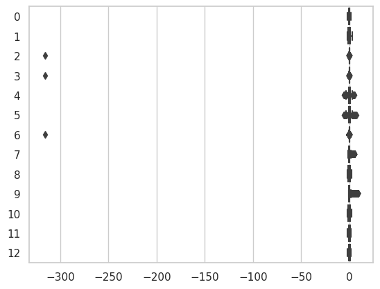

```python
import seaborn as sns

sns.set(style="whitegrid", font_scale=1.0)
sns.boxplot(data=X, palette="husl", orient="h");
```

Observamos que las variables 2 (u), 3(g) y 6(z) contienen outliers. Por lo tanto, procedo a eliminarlos para mejorar la precisión del modelo:

```python
import numpy as np

# Calculamos el IQR para cada columna
Q1 = np.percentile(X, 25, axis=0)
Q3 = np.percentile(X, 75, axis=0)
IQR = Q3 - Q1

# Definimos los límites de los outliers
lower_bound = Q1 - 1.5 * IQR
upper_bound = Q3 + 1.5 * IQR

# Definimos una máscara que indica dónde están los outliers para cada columna
outliers = (X < lower_bound) | (X > upper_bound)

# Eliminamos los outliers
X = X[~np.any(outliers, axis=1)]
y = y[~np.any(outliers, axis=1)]

print("Outliers eliminados correctamente")
```

```
Outliers eliminados correctamente
```

Creo un nuevo boxplot de los datos, ahora sin los outliers.

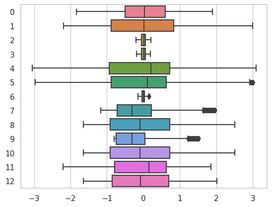

```python
import seaborn as sns

sns.set(style="whitegrid", font_scale=1.0)
sns.boxplot(data=X, palette="husl", orient="h");
```

Vamos a examinar la distribución de las clases de los objetos celestes, y observar la cantidad de estos en el conjunto de datos.

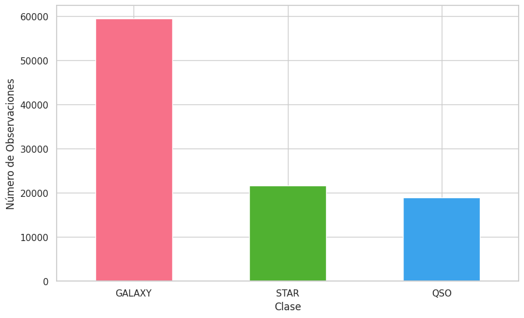

```python
import pandas as pd
import matplotlib.pyplot as plt
import seaborn as sns

# Conteo de las observaciones por clase
class_counts = df['class'].value_counts()

# Obtengo los colores de la paleta 'husl'
palette = sns.color_palette("husl", n_colors=class_counts.size)

# Mapeo cada clase a un color específico
color_map = dict(zip(class_counts.index, palette))

# Creo el gráfico de barras asignando los colores
plt.figure(figsize=(10,6))
class_counts.plot(kind='bar', color=[color_map[i] for i in class_counts.index])
plt.xlabel('Clase')
plt.ylabel('Número de Observaciones')
plt.xticks(rotation=0)
plt.show()
```

Gráfico de dispersión (SCATTERPLOT): relación entre las variables "alpha" y "delta". Para ver la asociación de ambas variables y comprobar su relacion con claridad.

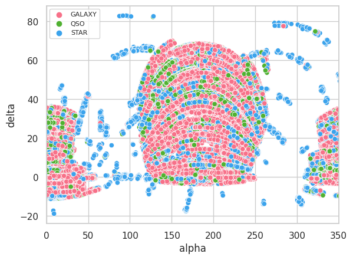

```python
import seaborn as sns
import matplotlib.pyplot as plt
%matplotlib inline

scatter_plot = sns.scatterplot(x="alpha", y="delta", hue="class", data=df, palette="husl")
scatter_plot.legend(prop={'size': 8})
plt.xlim(0, 350)
plt.show()
```

Gráficos de dispersión (PAIRPLOT): relación entre las variables "alpha" y "delta". Este gráfico muestra la relación entre el par de variables y cómo se relacionan con la variable "class".

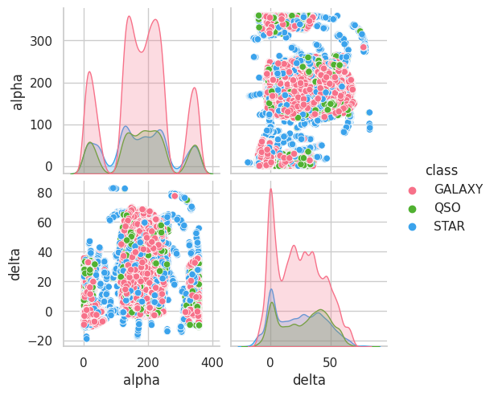

```python
import seaborn as sns
import matplotlib.pyplot as plt

# Selecciono solo las columnas que me interesan
selected_columns = df[["alpha", "delta"]]

# Creo el pairplot (escojo 1000 muestras aleatorias, ya que el dataset es muy amplio)
sns.pairplot(data=df, vars=selected_columns.sample(n=1000), hue='class',  palette="husl")

plt.show()
```

Gráficos de Densidad por Clase: para cada variable predictiva, se puede ver cómo se distribuye con respecto a cada clase, lo que puede indicar qué variables serán importantes para la clasificación.

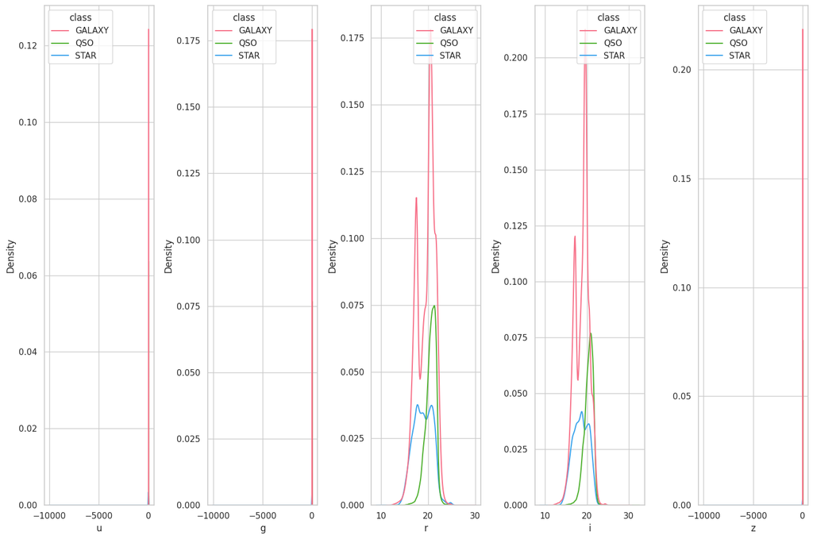

```python
import seaborn as sns
import matplotlib.pyplot as plt

# Ajusto el tamaño de la figura para que se ajuste a la cantidad de subplots
plt.figure(figsize=(15, 10))

# Lista de variables predictivas
predictive_vars = ['u', 'g', 'r', 'i', 'z']

# Creo un loop para generar un gráfico de densidad para cada variable predictiva
for i, var in enumerate(predictive_vars, 1):
    plt.subplot(1, len(predictive_vars), i)
    sns.kdeplot(data=df, x=var, hue='class', palette='husl')

plt.tight_layout()
plt.show()
```

Boxplot de los filtros brillantes

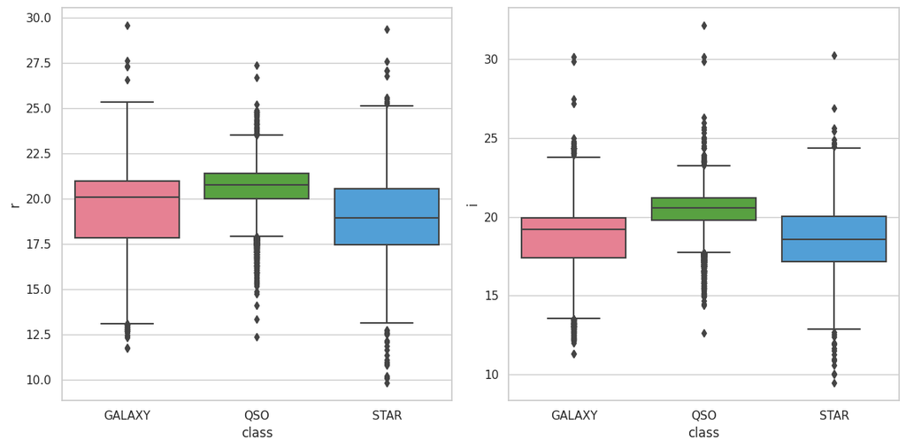

```python
import seaborn as sns
import matplotlib.pyplot as plt

# Establece el estilo del gráfico
sns.set(style="whitegrid")

# Lista de variables predictivas para las que hacer boxplots
predictive_vars = ['r', 'i']

# Configuro el tamaño del gráfico
plt.figure(figsize=(12, 6))

# Genero un boxplot para cada variable predictiva
for i, var in enumerate(predictive_vars):
    plt.subplot(1, len(predictive_vars), i + 1)
    sns.boxplot(x='class', y=var, data=df, palette='husl')

plt.tight_layout()
plt.show()
```

Gráficos de dispersión: relación entre las variables "u", "g", "r", "i" y "z.  
Estos gráficos muestran la relación entre cada par de variables y cómo se relacionan con la variable "class".

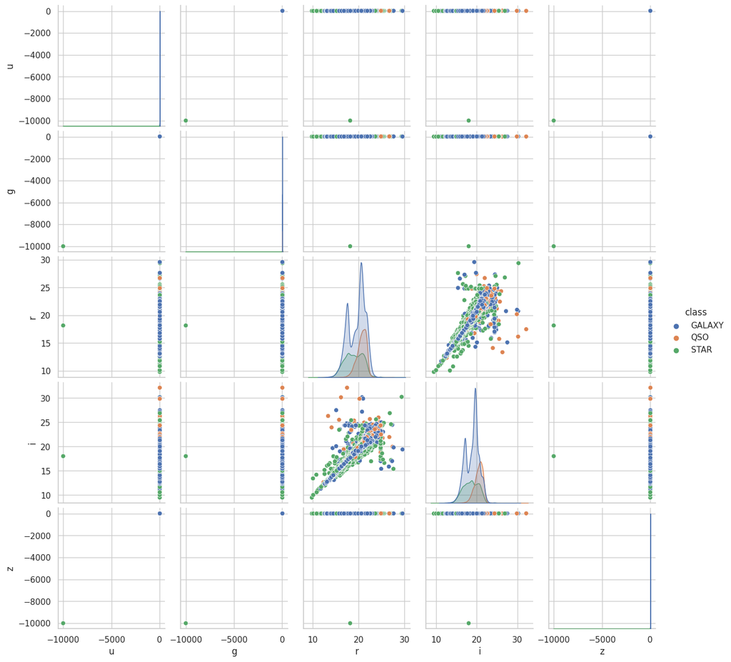

```python
import seaborn as sns
import matplotlib.pyplot as plt

# Selecciono solo las columnas que te interesan
selected_columns = df[["u", "g", "r", "i", "z"]]

# Creo el pairplot (escojo 1000 muestras aleatorias, ya que el dataset es muy amplio)
sns.pairplot(data=df, vars=selected_columns.sample(n=1000), hue='class')

plt.show()
```